# Approaching geovisualization and remote sensing with GeoViews

[figure not shown]

Link: http://bit.ly/geopython-basel

09/05/2018 @ GeoPython

Giacomo Debidda

## What is GeoViews?

A Python library that makes it easy to explore and visualize geographical, meteorological, oceanographic datasets.

- GIS extension for [Holoviews](http://holoviews.org/getting_started/Introduction.html)
- Declarative API: annotate your data and let it visualize itself
- Uses Cartopy for geographic projections
- Uses Shapely for geometries
- Allows to create plots from multidimesional dataset (gridded dataset)
- Makes it easy to overlay layers in a visualization
- Leverages many Python libraries: Pandas, GeoPandas, Xarray, Datashader, Matplotlib/Bokeh

## GeoViews objects

GeoViews objects are just like HoloViews objects...

...with an associated geographic projection based on a Coordinate Reference System defined in `cartopy.crs`.

GeoViews provides the `Feature` (`cartopy` features) and `Shape` (`shapely` geometries) types.

## Imports

We need `shapely` for geometries, `cartopy` and `pyproj` for projections, `geopandas` for spatial joins.

```python
import os
import pyproj
import numpy as np
import pandas as pd
import geopandas as gpd
import xarray as xr
import holoviews as hv
import geoviews as gv
import geoviews.feature as gf
import shapely as shp
import cartopy.io.shapereader as shpreader
import cartopy.crs as ccrs  # Cartopy coordinate reference system
import cartopy.feature as cf
import matplotlib.pyplot as plt
from bokeh.models import WMTSTileSource
from bokeh.tile_providers import STAMEN_TERRAIN, STAMEN_TONER
# import bokeh.sampledata
# bokeh.sampledata.download()  # this will download to /home/jack/.bokeh/data/
from bokeh.sampledata.airport_routes import airports, routes
```

```python
data_dir = os.path.join(os.getcwd(), 'data')
print(data_dir)
```

```
/home/jack/Repos/geopython-basel/data
```

## Choose a plotting backend

GeoViews (and HoloViews) can use either a Matplotlib backend or a Bokeh backend.

**Matplotlib**

**+** supports more projections

**-** less interactivity

**-** at the moment, it seems not possible to use Web Map Tile Services (WMTS)

**Bokeh**

**+** better interactivity

**+** can use Web Map Tile Services

**-** supports only the Mercator projection

Note: visual attributes have (slightly) different names in the plotting backends (e.g. `facecolor` in Matplotlib VS `fill_color` in Bokeh).

See [here](http://geo.holoviews.org/Projections.html) to know the projections supported by GeoViews.

```python
hv.notebook_extension('bokeh', 'matplotlib')
%output backend='matplotlib'
```

## `opts` (`OptsMagic`)

You can use the `%%opts` cell **magic command** to set some options (e.g. change the geographical projection).

`opts` is not a built-in magic command, it's provided by HoloViews.

See `OptsMagic` class in `holoviews.ipython.magics.py` and `OptsSpec` in `holoviews.util.parser` or call `%%opts?` in a notebook cell.

See [how to customize plots](http://holoviews.org/user_guide/Customizing_Plots.html) in the HoloViews documentation.

```python
%%output size=400
%%opts Feature [projection=ccrs.PlateCarree()]
gf.coastline
```

## Combining geographical features

You can create HoloViews layouts by combining and overlaying several GeoViews `Feature` elements.

You can use `hv.Overlay` or the `*` operator to combine several GeoViews features into a single HoloViews layout.

```python
%%output size=200
%%opts Feature [projection=ccrs.Geostationary()]
hv.Overlay([gf.coastline, gf.borders]) + gf.ocean * gf.rivers * gf.lakes
```

## GeoViews `Feature`

A GeoViews `Feature` is a Cartopy feature with additional properties and methods.

In fact, `gf.ocean` is just a shortcut for `gv.Feature(cf.OCEAN, group='Ocean')`.

See the docs for the [Cartopy Feature interface](http://scitools.org.uk/cartopy/docs/v0.14/matplotlib/feature_interface.html).

Here are the features currently available in `geoviews.feature.py`:

```
borders   = Feature(cf.BORDERS, group='Borders')
coastline = Feature(cf.COASTLINE, group='Coastline')
land      = Feature(cf.LAND, group='Land')
lakes     = Feature(cf.LAKES, group='Lakes')
ocean     = Feature(cf.OCEAN, group='Ocean')
rivers    = Feature(cf.RIVERS, group='Rivers')
```

## Create a GeoViews feature from Natural Earth

`cartopy` provides an interface to [Natural Earth](http://www.naturalearthdata.com/) shapefiles.

*Natural Earth* $\rightarrow$ *Cartopy* $\rightarrow$ *GeoViews*

Let's create a feature for the [graticules](http://desktop.arcgis.com/en/arcmap/10.3/map/page-layouts/what-are-grids-and-graticules-.htm).

First, create a Cartopy feature.

`scale` is the dataset scale, i.e. one of '10m', '50m', or '110m'.

Corresponding to 1:10,000,000, 1:50,000,000, and 1:110,000,000 respectively.

```python
cartopy_graticules = cf.NaturalEarthFeature(category='physical',
                                            name='graticules_30',
                                            scale='110m')
cartopy_graticules
```

```
<cartopy.feature.NaturalEarthFeature at 0x7fec6c0ed6d8>
```

Then, use the Cartopy feature to create a GeoViews feature.

```python
%%output size=200
%%opts Feature.Lines (facecolor='none' edgecolor='gray') [projection=ccrs.Robinson()]
graticules = gv.Feature(cartopy_graticules, group='Lines')
graticules
```

## Create a GeoViews `Feature` from any shapefile

Cartopy `shapereader` provides an interface for accessing the contents of a shapefile.

*Shapefile* $\rightarrow$ *Cartopy* $\rightarrow$ *GeoViews*

Shapefile: [American Indian/Alaska Native Areas/Hawaiian Home Lands](https://www.census.gov/geo/maps-data/data/cbf/cbf_aiannh.html) from United Stated Census Bureau.

```python
# Note: this file takes ~10s to be processed
shp_filepath = os.path.join(data_dir, 'tl_2017_us_aiannh', 'tl_2017_us_aiannh.shp')
reader = shpreader.Reader(shp_filepath)
# Note: you need to know the cartopy CRS in which the provided geometries are defined.
cartopy_homelands = cf.ShapelyFeature(geometries=reader.geometries(), crs=ccrs.PlateCarree())
cartopy_homelands
```

```
<cartopy.feature.ShapelyFeature at 0x7fec6bfbc5f8>
```

```python
%%time
%%output size=400
%%opts Feature.Lines (facecolor='none' edgecolor='black') [projection=ccrs.PlateCarree()]
homelands = gv.Feature(cartopy_homelands)
homelands_style = {'facecolor': 'red', 'alpha': 1.0}
homelands.opts(style=homelands_style)
```

```
CPU times: user 10.6 s, sys: 24 ms, total: 10.6 s
Wall time: 10.6 s
```

You can also avoid using Cartopy and read a shapefile with GeoPandas, or even directly with `gv.Shape` (a wrapper for Shapely's `Shape`).

*Shapefile* $\rightarrow$ *GeoViews*

Note: thanks to Shapely you don't need a GeoJSON (or TopoJSON) to build a geometry. You are using binary buffers to read the data.

```python
%%time
ndoverlay = gv.Shape.from_shapefile(shp_filepath)
```

```
CPU times: user 8.49 s, sys: 56 ms, total: 8.54 s
Wall time: 8.55 s
```

```python
%%time
%%output size=200
%%opts Shape (facecolor='red' alpha=1.0)
ndoverlay.relabel('American Indian/Alaska Native Areas/Hawaiian Home Lands')
```

```
CPU times: user 27 s, sys: 96 ms, total: 27.1 s
Wall time: 27.1 s
```

```python
%%time
%%output size=300
%%opts Feature [projection=ccrs.Robinson()]
layout = hv.Overlay([gf.ocean, gf.land, gf.coastline, graticules, homelands.opts(style=homelands_style)])
layout
```

```
CPU times: user 36.5 s, sys: 32 ms, total: 36.5 s
Wall time: 36.5 s
```

## All flights from Honolulu

Data:

`airports` and `routes` from `bokeh.sampledata.airport_routes`.

Code not showns in slides. See jupyter notebook.

```python
src = airports[airports.City == 'Honolulu'].iloc[0]
src
```

```
AirportID                              3728
Name         Honolulu International Airport
City                               Honolulu
Country                       United States
IATA                                    HNL
ICAO                                   PHNL
Latitude                            21.3187
Longitude                          -157.922
Altitude                                 13
Timezone                                -10
DST                                       N
TZ                         Pacific/Honolulu
Type                                airport
source                          OurAirports
Name: 311, dtype: object
```

```python
geo_projection = ccrs.Geostationary(central_longitude=src.Longitude)
```

```python
%%output size=400
%%opts Feature [projection=geo_projection]
%%opts Points (color='red' size=3) [projection=geo_projection]
%%opts Path (color='steelblue') [projection=geo_projection]
points = dataset.to(gv.Points, kdims=['Longitude', 'Latitude'], vdims=['Name'])
(gf.coastline * points * gv.Path(paths)).redim.range(
    Longitude=(src.Longitude-5, -50), Latitude=(src.Latitude-5, 80))
```

## Gridded Datasets

Data:

netCDF file (Air quality) from [NOAA](https://www.esrl.noaa.gov/psd/repository/entry/show?entryid=synth%3Ae570c8f9-ec09-4e89-93b4-babd5651e7a9%3AL25jZXAucmVhbmFseXNpcy5kZXJpdmVkL3N1cmZhY2UvYWlyLm1vbi5tZWFuLm5j) (National Oceanic and Atmospheric Administration).

```python
netcdf_filepath = os.path.join(data_dir, 'air.mon.mean.nc')
ds_air = xr.open_dataset(netcdf_filepath)
ds_air
```

```
<xarray.Dataset>
Dimensions:  (lat: 73, lon: 144, time: 840)
Coordinates:
  * lat      (lat) float32 90.0 87.5 85.0 82.5 80.0 77.5 75.0 72.5 70.0 67.5 ...
  * lon      (lon) float32 0.0 2.5 5.0 7.5 10.0 12.5 15.0 17.5 20.0 22.5 ...
  * time     (time) datetime64[ns] 1948-01-01 1948-02-01 1948-03-01 ...
Data variables:
    air      (time, lat, lon) float32 ...
Attributes:
    description:    Data from NCEP initialized reanalysis (4x/day).  These ar...
    platform:       Model
    Conventions:    COARDS
    NCO:            20121012
    history:        Thu May  4 20:11:16 2000: ncrcat -d time,0,623 /Datasets/...
    title:          monthly mean air.sig995 from the NCEP Reanalysis
    References:     http://www.esrl.noaa.gov/psd/data/gridded/data.ncep.reana...
    dataset_title:  NCEP-NCAR Reanalysis 1
```

```python
dataset = gv.Dataset(ds_air, label=ds_air.attrs['title'])
type(dataset)
```

```
geoviews.element.geo.Dataset
```

```python
img_air = dataset.to(gv.Image, kdims=['lon', 'lat'], dynamic=True)
type(img_air)
```

```
holoviews.core.spaces.DynamicMap
```

```python
%%time
%%opts Image [colorbar=True fig_size=400 xaxis=None yaxis=None] (cmap='viridis')
%%opts Feature [projection=ccrs.Robinson()]
dynamic_map = img_air * gf.borders * gf.coastline
dynamic_map
```

```
CPU times: user 5.66 s, sys: 8 ms, total: 5.66 s
Wall time: 5.79 s
```

## Web Map Tile Services (WMTS)

In order to use a map tiles you need to switch to a bokeh plotting backend.

```python
tiles = {
    'OpenMap': WMTSTileSource(url='http://c.tile.openstreetmap.org/{Z}/{X}/{Y}.png'),
    'ESRI': WMTSTileSource(url='https://server.arcgisonline.com/ArcGIS/rest/services/World_Imagery/MapServer/tile/{Z}/{Y}/{X}.jpg'),
    'Wikipedia': WMTSTileSource(url='https://maps.wikimedia.org/osm-intl/{Z}/{X}/{Y}@2x.png'),
    # 'STAMEN_TONER': STAMEN_TONER,
    'STAMEN_TERRAIN': STAMEN_TERRAIN
}
```

Note: at the moment, bokeh supports only the web Mercator projection. See [here](http://geo.holoviews.org/user_guide/Working_with_Bokeh.html).

```python
hv.notebook_extension('bokeh')
```

```python
%%opts WMTS [width=450 height=250 xaxis=None yaxis=None]
# click on the "Wheel Zoom" tool and zoom out
hv.NdLayout(
    {name: gv.WMTS(wmts, extents=(0, -90, 360, 90), crs=ccrs.PlateCarree())
     for name, wmts in tiles.items()}, kdims=['Source']
).cols(2)
```

## Basel's City Districts, Parks and Cafes

Data:

Basel districts shapefile from [OpenStreetMap](https://wiki.openstreetmap.org/wiki/City_of_Basel_Suburb_Import) (raw data, not the `.osm` file).

Basel parks and cafes shapefile from [BBBike](https://extract.bbbike.org/).

```python
basel_somerc = gpd.read_file(os.path.join(data_dir, 'WE_StatWohneinteilungen', 'Wohnviertel.shp'))
print(basel_somerc.crs)
basel_somerc.head()
```

```
INFO:Fiona:Failed to auto identify EPSG: 7
```

```
{'proj': 'somerc', 'lat_0': 46.95240555555556, 'lon_0': 7.439583333333333, 'k_0': 1, 'x_0': 2600000, 'y_0': 1200000, 'ellps': 'bessel', 'units': 'm', 'no_defs': True}
```

|  | OBJID | OBJECTID | TXT | ZTXT | TYPE | geometry |
| --- | --- | --- | --- | --- | --- | --- |
| 0 | 17136 | 1 | 7 | 07 | Bruderholz | POLYGON ((2612555.909 1264547.542, 2612560.552... |
| 1 | 17139 | 2 | 6 | 06 | Gundeldingen | POLYGON ((2610887.105 1266551.468, 2610896.202... |
| 2 | 17142 | 3 | 5 | 05 | St. Alban | POLYGON ((2612941.971 1267023.045, 2613000.085... |
| 3 | 17145 | 4 | 4 | 04 | Breite | POLYGON ((2613683.78 1266891.09, 2613686.423 1... |
| 4 | 17148 | 5 | 8 | 08 | Bachletten | POLYGON ((2610560.968 1266791.31, 2610571.054 ... |

## Convert 21781 (CH1903) to 4326 (WGS84)

You can use `pyproj.Proj` and reproject manually...

```python
# https://gis.stackexchange.com/a/277488/119309
input_projection = pyproj.Proj(init='EPSG:21781')
output_projection = pyproj.Proj(init='EPSG:4326')
pyproj.transform(input_projection, output_projection, x=basel_somerc.crs['x_0'], y=basel_somerc.crs['y_0'])
```

```
(37.37899200094729, 52.46327489367161)
```

```python
polygons_somerc = [basel_somerc.loc[i, 'geometry']
                   for i in range(basel_somerc.shape[0])]
```

```python
polygons_wgs84 = []
for poly in polygons_somerc:
    x, y = poly.exterior.coords.xy
    x_new, y_new = pyproj.transform(input_projection, output_projection, x, y)
    poly_new = shp.geometry.Polygon(list(zip(x_new, y_new)))
    polygons_wgs84.append(poly_new)
```

```python
polygons_somerc[0]
```

```python
polygons_wgs84[0]
```

...or use GeoPandas and its `to_crs` method.

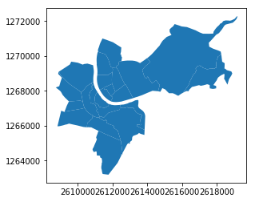

```python
basel_somerc.plot()
```

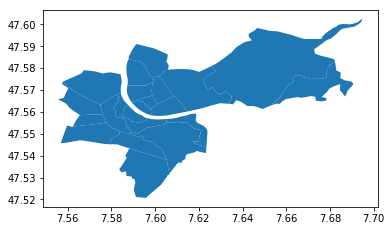

```python
basel_wgs84 = basel_somerc.to_crs(epsg=4326)
basel_wgs84.plot()
```

## Add a centroid for each district

```python
basel_wgs84['CentroidLongitude'] = basel_wgs84['geometry'].apply(lambda poly: poly.centroid.bounds[0])
basel_wgs84['CentroidLatitude'] = basel_wgs84['geometry'].apply(lambda poly: poly.centroid.bounds[1])
basel_wgs84.head()
```

|  | OBJID | OBJECTID | TXT | ZTXT | TYPE | geometry | CentroidLongitude | CentroidLatitude |
| --- | --- | --- | --- | --- | --- | --- | --- | --- |
| 0 | 17136 | 1 | 7 | 07 | Bruderholz | POLYGON ((7.606348201652279 47.53293165390978,... | 7.595473 | 47.532624 |
| 1 | 17139 | 2 | 6 | 06 | Gundeldingen | POLYGON ((7.584232669336745 47.55098643373825,... | 7.592170 | 47.545054 |
| 2 | 17142 | 3 | 5 | 05 | St. Alban | POLYGON ((7.611547896278745 47.55519084800139,... | 7.608627 | 47.546740 |
| 3 | 17145 | 4 | 4 | 04 | Breite | POLYGON ((7.621400475031203 47.55398888665725,... | 7.617374 | 47.553016 |
| 4 | 17148 | 5 | 8 | 08 | Bachletten | POLYGON ((7.57990522852878 47.55314909549825, ... | 7.570503 | 47.550043 |

## Basel's parks

Apparently there are some issues with the shapefile I extracted from [BBBike](https://extract.bbbike.org/). Many shapely records are invalid.

Because of these invalid records, `gv.Shape.from_shapefile` does not work.

Luckily enough, you can use `cartopy.shapereader.Reader` and filter out these records with a simple condition.

```python
shp_filepath = os.path.join(data_dir, 'basel_shapefiles', 'natural.shp')
reader = shpreader.Reader(shp_filepath)
```

```python
parks_generator = (r for r in reader.records() if r.attributes['type'] == 'park')
parks = [p for p in parks_generator if p.geometry.area > 0]
```

```python
park_geometries = [p.geometry for p in parks]
print(parks[0].attributes)
park_geometries[0]
```

```
{'osm_id': 12362783, 'name': 'Kannenfeldpark', 'type': 'park'}
```

```python
# some parks have no name. Maybe they are just small (private?) green areas...
', '.join([p.attributes['name'] for p in parks])
```

```
'Kannenfeldpark, , Buremichelskopfanlage, Schützenmattpark, Helvetiaplatz, Benkenpark, Theodorsgraben-Anlage, Rosenfeldpark, Christoph Merian-Park, Dreirosenanlage, Elisabethenanlage, Oekolampadpark, Verkehrspark, , , St.Johanns-Platz, St.Johanns-Platz, St.Johanns-Platz, Totentanz, Petersplatz, Tier…
```

```python
%%opts Shape (fill_color='green')
gv.Shape(park_geometries[0]) * gv.Text(7.5704, 47.5653, parks[0].attributes['name'])
```

## Basel's Cafes

```python
shp_filepath = os.path.join(data_dir, 'basel_shapefiles', 'points.shp')
reader = shpreader.Reader(shp_filepath)
```

```python
cafes = [r for r in reader.records() if r.attributes['type'] == 'cafe']
f'There are {len(cafes)} cafes in Basel'
```

```
'There are 74 cafes in Basel'
```

```python
cafes[0].geometry.bounds
```

```
(7.5938822, 47.5692456, 7.5938822, 47.5692456)
```

```python
cafes_data = list(map(lambda x: (x.geometry.bounds[0], x.geometry.bounds[1], x.attributes['name']), cafes))
```

```python
cafes_df = pd.DataFrame(cafes_data, columns=['Longitude', 'Latitude', 'Name'])
cafes_df.head()
```

|  | Longitude | Latitude | Name |
| --- | --- | --- | --- |
| 0 | 7.593882 | 47.569246 | Senat Maki's |
| 1 | 7.588602 | 47.567340 | Per Tutti |
| 2 | 7.590183 | 47.567713 | Ticino |
| 3 | 7.588983 | 47.575878 |  |
| 4 | 7.592869 | 47.566456 | Da Graziella |

```python
cafes_dataset = gv.Dataset(cafes_df, kdims=['Name'])
```

```python
%%opts WMTS [width=800 height=600]
%%opts Shape (fill_color='green' fill_alpha=0.5)
%%opts Points (color='orange' line_color='black' size=7) [tools=['hover']]
hv.Overlay([
    gv.WMTS(tiles['ESRI'], crs=ccrs.PlateCarree()),
    hv.NdOverlay({i: gv.Shape(pg, crs=ccrs.PlateCarree()) for i, pg in enumerate(park_geometries)}),
    cafes_dataset.to(gv.Points, kdims=['Longitude', 'Latitude'], vdims=['Name'], crs=ccrs.PlateCarree()),
])
```

```python
%%output size=600
hv.Overlay([
    hv.NdOverlay({i: shape_district(poly) for i, poly in enumerate(basel_wgs84.geometry)}),
    hv.NdOverlay({i: shape_park(poly) for i, poly in enumerate(park_geometries)}),
    hv.NdOverlay({i: text_centroid(lon, lat, name) for i, (lon, lat, name) in enumerate(list_centroid)}),
    cafe_points.opts(style={'color': 'orange', 'edgecolor': 'black', 's': 50}),
])
```

## Districts with the highest number of Cafes?

```python
names = []
points = []
for i, cafe in cafes_df.iterrows():
    names.append(cafe.Name)
    points.append(shp.geometry.Point((cafe.Longitude, cafe.Latitude)))

cafes_gdf = gpd.GeoDataFrame({'Cafe': names, 'geometry': points}, crs={'init': 'epsg:4326', 'no_defs': True})
cafes_gdf.head()
```

|  | Cafe | geometry |
| --- | --- | --- |
| 0 | Senat Maki's | POINT (7.5938822 47.5692456) |
| 1 | Per Tutti | POINT (7.5886017 47.5673398) |
| 2 | Ticino | POINT (7.5901833 47.567713) |
| 3 |  | POINT (7.5889833 47.5758776) |
| 4 | Da Graziella | POINT (7.5928691 47.5664559) |

```python
districts_and_cafes = gpd.sjoin(basel_wgs84[['TYPE', 'geometry']], cafes_gdf, how="left", op='contains')
# districts_and_cafes.head()
```

```python
cafes_count = districts_and_cafes.groupby('TYPE')[['Cafe']].count().rename(columns={'Cafe': 'CafeCount'})
cafes_in_basel = cafes_count.sort_values(by='CafeCount', ascending=False).reset_index()
# cafes_in_basel.head()
```

```python
gdf = pd.merge(basel_wgs84[['TYPE', 'geometry']], cafes_in_basel)
gdf.sort_values(by='CafeCount', ascending=False).head()
```

|  | TYPE | geometry | CafeCount |
| --- | --- | --- | --- |
| 18 | Matthäus | POLYGON ((7.598904359545449 47.57318222535969,... | 12 |
| 5 | Vorstädte | POLYGON ((7.58481814196309 47.56691635597112, ... | 12 |
| 1 | Gundeldingen | POLYGON ((7.584232669336745 47.55098643373825,... | 11 |
| 10 | St. Johann | POLYGON ((7.572597585628209 47.57850891520469,... | 7 |
| 9 | Iselin | POLYGON ((7.575575941753982 47.56093059715941,... | 4 |

```python
%%output size=400
%%opts Polygons (cmap='YlOrRd') [color_index='CafeCount' colorbar=True]
gv.Polygons(gdf, vdims=['TYPE', 'CafeCount'], label='Cafes in Basel districts')
```

## Big Data?

Use GeoViews (HoloViews) + Datashader + Matplotlib/Bokeh.

The combination [HoloViews + Datashader](https://anaconda.org/jbednar/holoviews_datashader/notebook) lets you switch between Datashader and non-Datashader plots generated by Matplotlib or Bokeh.

NYC yellow taxi visualization @ [hdf5-pydata-munich](https://github.com/jackdbd/hdf5-pydata-munich/blob/master/hdf5_in_python.ipynb)

[figure not shown]

## Datashader

Datashader is a data [rasterization pipeline](http://datashader.org/getting_started/2_Pipeline.html) similar to a 3D graphics shading pipeline.

1. Projection: *Data* $\rightarrow$ *Scene*
2. Aggregation: *Scene* $\rightarrow$ *Aggregates* (an aggregate bin ends up in one pixel)
3. Transformation + Colormapping: *Aggregates* $\rightarrow$ *Image*
4. Embedding: *Image* $\rightarrow$ *Plot*

This approach allows you to plot a lot of data, and to avoid [plotting pitfalls](https://anaconda.org/jbednar/plotting_pitfalls/notebook) such as:

- overplotting
- oversaturation
- undersampling
- undersaturation
- underutilized range
- nonuniform colormapping

## A few resources on Datashader

[How Datashader works](https://www.youtube.com/watch?v=6m3CFbKmK_c)

[PyViz](https://github.com/pyviz/pyviz): how to solve visualization problems with Python tools.

James Bednar's notebooks:

- [nyc_taxi](https://anaconda.org/jbednar/nyc_taxi/notebook)
- [census](https://anaconda.org/jbednar/census/notebook)
- [census-hv-dask](https://anaconda.org/jbednar/census-hv-dask/notebook)
- [landsat](https://anaconda.org/jbednar/landsat/notebook)
- [water depth (trimesh)](http://datashader.org/topics/bay_trimesh.html)

Guillem Duran Ballester's [talk @ EuroPython 2017](https://www.youtube.com/watch?v=JUErYqjf5Zw) with AirBnB data.

Johnny Chan's Bokeh app on [UK road accidents](https://github.com/Atlas7/bokeh-app-uk-road-accidents-viz).

## Thank You!

GitHub repo @ http://bit.ly/geopython-basel.

I'm also on Twitter [@jackdbd](https://twitter.com/jackdbd).